# Risk Factor Analysis

## Outcome Variable

**Outcome Variable:** wasted

## Predictor Variables

**Intervention Variable:** mhtcm

**Adjustment Set:**

unadjusted

## Stratifying Variables

The analysis was stratified on these variable(s):

- agecat
- studyid
- country

## Data Summary

| agecat | studyid | country | mhtcm | wasted | n_cell | n |
| --- | --- | --- | --- | --- | --- | --- |
| Birth | ki0047075b-MAL-ED | BANGLADESH | >=155 cm | 0 | 21 | 233 |
| Birth | ki0047075b-MAL-ED | BANGLADESH | >=155 cm | 1 | 3 | 233 |
| Birth | ki0047075b-MAL-ED | BANGLADESH | <151 cm | 0 | 121 | 233 |
| Birth | ki0047075b-MAL-ED | BANGLADESH | <151 cm | 1 | 24 | 233 |
| Birth | ki0047075b-MAL-ED | BANGLADESH | [151-155) cm | 0 | 52 | 233 |
| Birth | ki0047075b-MAL-ED | BANGLADESH | [151-155) cm | 1 | 12 | 233 |
| Birth | ki0047075b-MAL-ED | BRAZIL | >=155 cm | 0 | 101 | 176 |
| Birth | ki0047075b-MAL-ED | BRAZIL | >=155 cm | 1 | 4 | 176 |
| Birth | ki0047075b-MAL-ED | BRAZIL | <151 cm | 0 | 44 | 176 |
| Birth | ki0047075b-MAL-ED | BRAZIL | <151 cm | 1 | 2 | 176 |
| Birth | ki0047075b-MAL-ED | BRAZIL | [151-155) cm | 0 | 25 | 176 |
| Birth | ki0047075b-MAL-ED | BRAZIL | [151-155) cm | 1 | 0 | 176 |
| Birth | ki0047075b-MAL-ED | INDIA | >=155 cm | 0 | 38 | 195 |
| Birth | ki0047075b-MAL-ED | INDIA | >=155 cm | 1 | 7 | 195 |
| Birth | ki0047075b-MAL-ED | INDIA | <151 cm | 0 | 77 | 195 |
| Birth | ki0047075b-MAL-ED | INDIA | <151 cm | 1 | 17 | 195 |
| Birth | ki0047075b-MAL-ED | INDIA | [151-155) cm | 0 | 48 | 195 |
| Birth | ki0047075b-MAL-ED | INDIA | [151-155) cm | 1 | 8 | 195 |
| Birth | ki0047075b-MAL-ED | NEPAL | >=155 cm | 0 | 25 | 167 |
| Birth | ki0047075b-MAL-ED | NEPAL | >=155 cm | 1 | 2 | 167 |
| Birth | ki0047075b-MAL-ED | NEPAL | <151 cm | 0 | 81 | 167 |
| Birth | ki0047075b-MAL-ED | NEPAL | <151 cm | 1 | 12 | 167 |
| Birth | ki0047075b-MAL-ED | NEPAL | [151-155) cm | 0 | 41 | 167 |
| Birth | ki0047075b-MAL-ED | NEPAL | [151-155) cm | 1 | 6 | 167 |
| Birth | ki0047075b-MAL-ED | PERU | >=155 cm | 0 | 55 | 269 |
| Birth | ki0047075b-MAL-ED | PERU | >=155 cm | 1 | 1 | 269 |
| Birth | ki0047075b-MAL-ED | PERU | <151 cm | 0 | 152 | 269 |
| Birth | ki0047075b-MAL-ED | PERU | <151 cm | 1 | 4 | 269 |
| Birth | ki0047075b-MAL-ED | PERU | [151-155) cm | 0 | 56 | 269 |
| Birth | ki0047075b-MAL-ED | PERU | [151-155) cm | 1 | 1 | 269 |

[output cut: 318 more lines]

The following strata were considered:

- agecat: 24 months, studyid: ki0047075b-MAL-ED, country: BANGLADESH
- agecat: 24 months, studyid: ki0047075b-MAL-ED, country: BRAZIL
- agecat: 24 months, studyid: ki0047075b-MAL-ED, country: INDIA
- agecat: 24 months, studyid: ki0047075b-MAL-ED, country: NEPAL
- agecat: 24 months, studyid: ki0047075b-MAL-ED, country: PERU
- agecat: 24 months, studyid: ki0047075b-MAL-ED, country: SOUTH AFRICA
- agecat: 24 months, studyid: ki0047075b-MAL-ED, country: TANZANIA, UNITED REPUBLIC OF
- agecat: 24 months, studyid: ki1017093-NIH-Birth, country: BANGLADESH
- agecat: 24 months, studyid: ki1017093b-PROVIDE, country: BANGLADESH
- agecat: 24 months, studyid: ki1017093c-NIH-Crypto, country: BANGLADESH
- agecat: 24 months, studyid: ki1066203-TanzaniaChild2, country: TANZANIA, UNITED REPUBLIC OF
- agecat: 24 months, studyid: ki1101329-Keneba, country: GAMBIA
- agecat: 24 months, studyid: ki1119695-PROBIT, country: BELARUS
- agecat: 24 months, studyid: ki1126311-ZVITAMBO, country: ZIMBABWE
- agecat: 24 months, studyid: ki1135781-COHORTS, country: GUATEMALA
- agecat: 24 months, studyid: ki1135781-COHORTS, country: INDIA
- agecat: 24 months, studyid: ki1135781-COHORTS, country: PHILIPPINES
- agecat: 24 months, studyid: ki1148112-LCNI-5, country: MALAWI
- agecat: 24 months, studyid: kiGH5241-JiVitA-3, country: BANGLADESH
- agecat: 6 months, studyid: ki0047075b-MAL-ED, country: BANGLADESH
- agecat: 6 months, studyid: ki0047075b-MAL-ED, country: BRAZIL
- agecat: 6 months, studyid: ki0047075b-MAL-ED, country: INDIA
- agecat: 6 months, studyid: ki0047075b-MAL-ED, country: NEPAL
- agecat: 6 months, studyid: ki0047075b-MAL-ED, country: PERU
- agecat: 6 months, studyid: ki0047075b-MAL-ED, country: SOUTH AFRICA
- agecat: 6 months, studyid: ki0047075b-MAL-ED, country: TANZANIA, UNITED REPUBLIC OF
- agecat: 6 months, studyid: ki1000304b-SAS-CompFeed, country: INDIA
- agecat: 6 months, studyid: ki1000304b-SAS-FoodSuppl, country: INDIA
- agecat: 6 months, studyid: ki1017093-NIH-Birth, country: BANGLADESH
- agecat: 6 months, studyid: ki1017093b-PROVIDE, country: BANGLADESH
- agecat: 6 months, studyid: ki1017093c-NIH-Crypto, country: BANGLADESH
- agecat: 6 months, studyid: ki1066203-TanzaniaChild2, country: TANZANIA, UNITED REPUBLIC OF
- agecat: 6 months, studyid: ki1101329-Keneba, country: GAMBIA
- agecat: 6 months, studyid: ki1112895-Guatemala BSC, country: GUATEMALA
- agecat: 6 months, studyid: ki1119695-PROBIT, country: BELARUS
- agecat: 6 months, studyid: ki1126311-ZVITAMBO, country: ZIMBABWE
- agecat: 6 months, studyid: ki1135781-COHORTS, country: GUATEMALA
- agecat: 6 months, studyid: ki1135781-COHORTS, country: INDIA
- agecat: 6 months, studyid: ki1135781-COHORTS, country: PHILIPPINES
- agecat: 6 months, studyid: ki1148112-LCNI-5, country: MALAWI
- agecat: 6 months, studyid: kiGH5241-JiVitA-3, country: BANGLADESH
- agecat: Birth, studyid: ki0047075b-MAL-ED, country: BANGLADESH
- agecat: Birth, studyid: ki0047075b-MAL-ED, country: BRAZIL
- agecat: Birth, studyid: ki0047075b-MAL-ED, country: INDIA
- agecat: Birth, studyid: ki0047075b-MAL-ED, country: NEPAL
- agecat: Birth, studyid: ki0047075b-MAL-ED, country: PERU
- agecat: Birth, studyid: ki0047075b-MAL-ED, country: SOUTH AFRICA
- agecat: Birth, studyid: ki0047075b-MAL-ED, country: TANZANIA, UNITED REPUBLIC OF
- agecat: Birth, studyid: ki1000304b-SAS-CompFeed, country: INDIA
- agecat: Birth, studyid: ki1017093-NIH-Birth, country: BANGLADESH
- agecat: Birth, studyid: ki1017093c-NIH-Crypto, country: BANGLADESH
- agecat: Birth, studyid: ki1101329-Keneba, country: GAMBIA
- agecat: Birth, studyid: ki1119695-PROBIT, country: BELARUS
- agecat: Birth, studyid: ki1126311-ZVITAMBO, country: ZIMBABWE
- agecat: Birth, studyid: ki1135781-COHORTS, country: GUATEMALA
- agecat: Birth, studyid: ki1135781-COHORTS, country: INDIA
- agecat: Birth, studyid: ki1135781-COHORTS, country: PHILIPPINES
- agecat: Birth, studyid: kiGH5241-JiVitA-3, country: BANGLADESH

### Dropped Strata

Some strata were dropped due to rare outcomes:

- agecat: Birth, studyid: ki0047075b-MAL-ED, country: BANGLADESH
- agecat: Birth, studyid: ki0047075b-MAL-ED, country: BRAZIL
- agecat: Birth, studyid: ki0047075b-MAL-ED, country: NEPAL
- agecat: Birth, studyid: ki0047075b-MAL-ED, country: PERU
- agecat: Birth, studyid: ki0047075b-MAL-ED, country: SOUTH AFRICA
- agecat: Birth, studyid: ki0047075b-MAL-ED, country: TANZANIA, UNITED REPUBLIC OF
- agecat: Birth, studyid: ki1000304b-SAS-CompFeed, country: INDIA
- agecat: Birth, studyid: ki1017093-NIH-Birth, country: BANGLADESH
- agecat: Birth, studyid: ki1017093c-NIH-Crypto, country: BANGLADESH
- agecat: Birth, studyid: ki1101329-Keneba, country: GAMBIA
- agecat: 6 months, studyid: ki0047075b-MAL-ED, country: BANGLADESH
- agecat: 6 months, studyid: ki0047075b-MAL-ED, country: BRAZIL
- agecat: 6 months, studyid: ki0047075b-MAL-ED, country: INDIA
- agecat: 6 months, studyid: ki0047075b-MAL-ED, country: NEPAL
- agecat: 6 months, studyid: ki0047075b-MAL-ED, country: PERU
- agecat: 6 months, studyid: ki0047075b-MAL-ED, country: SOUTH AFRICA
- agecat: 6 months, studyid: ki0047075b-MAL-ED, country: TANZANIA, UNITED REPUBLIC OF
- agecat: 6 months, studyid: ki1017093c-NIH-Crypto, country: BANGLADESH
- agecat: 6 months, studyid: ki1112895-Guatemala BSC, country: GUATEMALA
- agecat: 6 months, studyid: ki1119695-PROBIT, country: BELARUS
- agecat: 6 months, studyid: ki1135781-COHORTS, country: GUATEMALA
- agecat: 6 months, studyid: ki1148112-LCNI-5, country: MALAWI
- agecat: 24 months, studyid: ki0047075b-MAL-ED, country: BANGLADESH
- agecat: 24 months, studyid: ki0047075b-MAL-ED, country: BRAZIL
- agecat: 24 months, studyid: ki0047075b-MAL-ED, country: INDIA
- agecat: 24 months, studyid: ki0047075b-MAL-ED, country: NEPAL
- agecat: 24 months, studyid: ki0047075b-MAL-ED, country: PERU
- agecat: 24 months, studyid: ki0047075b-MAL-ED, country: SOUTH AFRICA
- agecat: 24 months, studyid: ki0047075b-MAL-ED, country: TANZANIA, UNITED REPUBLIC OF
- agecat: 24 months, studyid: ki1066203-TanzaniaChild2, country: TANZANIA, UNITED REPUBLIC OF
- agecat: 24 months, studyid: ki1119695-PROBIT, country: BELARUS
- agecat: 24 months, studyid: ki1148112-LCNI-5, country: MALAWI

## Methods Detail

We’re interested in the causal parameters $E[Y_a]$ for all values of $a \in \mathcal{A}$. These parameters represent the mean outcome if, possibly contrary to fact, we intervened to set all units to have $A=a$. Under the randomization and positivity assumptions, these are identified by the statistical parameters $\psi_a=E_W[E_{Y|A,W}(Y|A=a,W)]$. In addition, we’re interested in the mean of $Y$, $E[Y]$ under no intervention (the observed mean). We will estimate these parameters by using SuperLearner to fit the relevant likelihood factors – $E_{Y|A,W}(Y|A=a,W)$ and $p(A=a|W)$, and then updating our likelihood fit using a joint TMLE.

For unadjusted analyses ($W=\{\}$), initial likelihoods were estimated using Lrnr_glm to estimate the simple $E(Y|A)$ and Lrnr_mean to estimate $p(A)$. For adjusted analyses, a small library containing Lrnr_glmnet, Lrnr_xgboost, and Lrnr_mean was used.

Having estimated these parameters, we will then use the delta method to estimate relative risks and attributable risks relative to a prespecified baseline level of $A$.

# Results Detail

## Results Plots

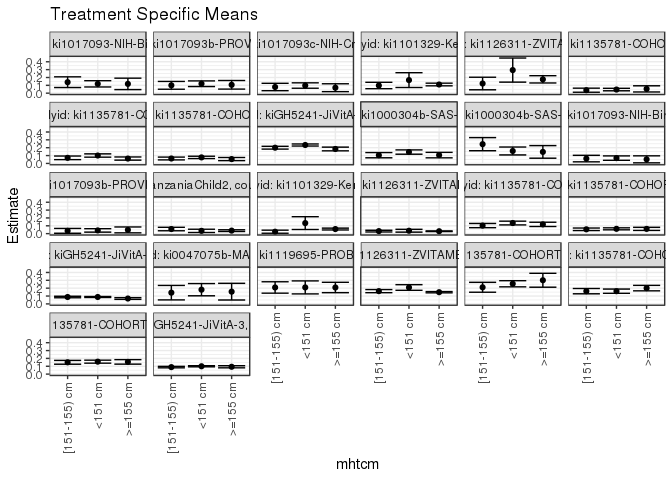

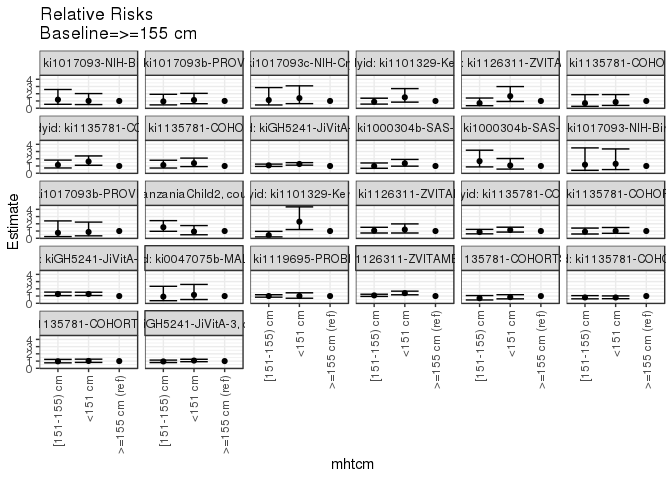

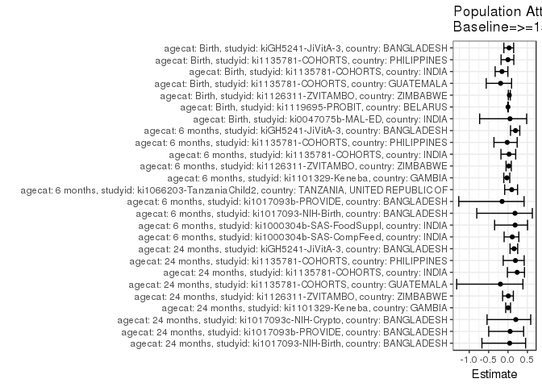

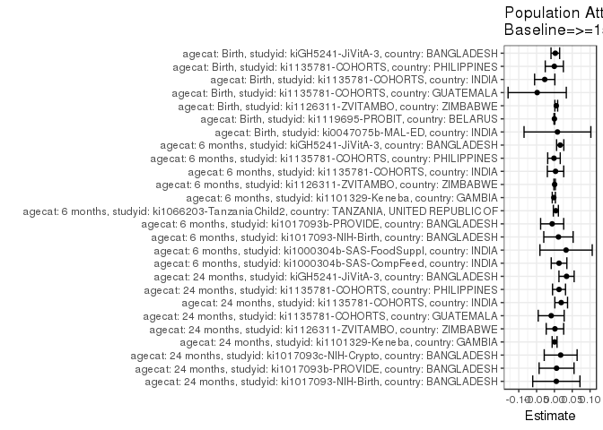

## Results Table

### Parameter: TSM

| agecat | studyid | country | intervention_level | baseline_level | estimate | ci_lower | ci_upper |
| --- | --- | --- | --- | --- | --- | --- | --- |
| Birth | ki0047075b-MAL-ED | INDIA | >=155 cm | NA | 0.1555556 | 0.0493893 | 0.2617218 |
| Birth | ki0047075b-MAL-ED | INDIA | <151 cm | NA | 0.1808511 | 0.1028424 | 0.2588597 |
| Birth | ki0047075b-MAL-ED | INDIA | [151-155) cm | NA | 0.1428571 | 0.0509714 | 0.2347429 |
| Birth | ki1119695-PROBIT | BELARUS | >=155 cm | NA | 0.2086851 | 0.1428507 | 0.2745194 |
| Birth | ki1119695-PROBIT | BELARUS | <151 cm | NA | 0.2096774 | 0.1270188 | 0.2923361 |
| Birth | ki1119695-PROBIT | BELARUS | [151-155) cm | NA | 0.2090680 | 0.1366772 | 0.2814588 |
| Birth | ki1126311-ZVITAMBO | ZIMBABWE | >=155 cm | NA | 0.1488423 | 0.1406522 | 0.1570325 |
| Birth | ki1126311-ZVITAMBO | ZIMBABWE | <151 cm | NA | 0.2088353 | 0.1731333 | 0.2445374 |
| Birth | ki1126311-ZVITAMBO | ZIMBABWE | [151-155) cm | NA | 0.1624521 | 0.1424381 | 0.1824661 |
| Birth | ki1135781-COHORTS | GUATEMALA | >=155 cm | NA | 0.3009709 | 0.2123309 | 0.3896109 |
| Birth | ki1135781-COHORTS | GUATEMALA | <151 cm | NA | 0.2561983 | 0.2172819 | 0.2951147 |
| Birth | ki1135781-COHORTS | GUATEMALA | [151-155) cm | NA | 0.2111801 | 0.1480929 | 0.2742673 |
| Birth | ki1135781-COHORTS | INDIA | >=155 cm | NA | 0.2007874 | 0.1659420 | 0.2356328 |
| Birth | ki1135781-COHORTS | INDIA | <151 cm | NA | 0.1615169 | 0.1344777 | 0.1885561 |
| Birth | ki1135781-COHORTS | INDIA | [151-155) cm | NA | 0.1622807 | 0.1284292 | 0.1961322 |
| Birth | ki1135781-COHORTS | PHILIPPINES | >=155 cm | NA | 0.1558442 | 0.1271965 | 0.1844918 |
| Birth | ki1135781-COHORTS | PHILIPPINES | <151 cm | NA | 0.1584775 | 0.1396451 | 0.1773099 |
| Birth | ki1135781-COHORTS | PHILIPPINES | [151-155) cm | NA | 0.1503580 | 0.1261543 | 0.1745617 |
| Birth | kiGH5241-JiVitA-3 | BANGLADESH | >=155 cm | NA | 0.0934724 | 0.0802251 | 0.1067196 |
| Birth | kiGH5241-JiVitA-3 | BANGLADESH | <151 cm | NA | 0.1000335 | 0.0933058 | 0.1067613 |
| Birth | kiGH5241-JiVitA-3 | BANGLADESH | [151-155) cm | NA | 0.0890078 | 0.0798396 | 0.0981759 |
| 6 months | ki1000304b-SAS-CompFeed | INDIA | >=155 cm | NA | 0.1060904 | 0.0713330 | 0.1408477 |
| 6 months | ki1000304b-SAS-CompFeed | INDIA | <151 cm | NA | 0.1448931 | 0.1174996 | 0.1722866 |
| 6 months | ki1000304b-SAS-CompFeed | INDIA | [151-155) cm | NA | 0.1047297 | 0.0714672 | 0.1379923 |
| 6 months | ki1000304b-SAS-FoodSuppl | INDIA | >=155 cm | NA | 0.1466667 | 0.0664959 | 0.2268375 |
| 6 months | ki1000304b-SAS-FoodSuppl | INDIA | <151 cm | NA | 0.1584158 | 0.1079968 | 0.2088348 |
| 6 months | ki1000304b-SAS-FoodSuppl | INDIA | [151-155) cm | NA | 0.2450980 | 0.1615114 | 0.3286847 |
| 6 months | ki1017093-NIH-Birth | BANGLADESH | >=155 cm | NA | 0.0520833 | 0.0075944 | 0.0965723 |
| 6 months | ki1017093-NIH-Birth | BANGLADESH | <151 cm | NA | 0.0677419 | 0.0397412 | 0.0957427 |
| 6 months | ki1017093-NIH-Birth | BANGLADESH | [151-155) cm | NA | 0.0615385 | 0.0201896 | 0.1028873 |
| 6 months | ki1017093b-PROVIDE | BANGLADESH | >=155 cm | NA | 0.0476190 | 0.0104028 | 0.0848353 |
| 6 months | ki1017093b-PROVIDE | BANGLADESH | <151 cm | NA | 0.0412698 | 0.0192846 | 0.0632551 |
| 6 months | ki1017093b-PROVIDE | BANGLADESH | [151-155) cm | NA | 0.0357143 | 0.0049475 | 0.0664811 |
| 6 months | ki1066203-TanzaniaChild2 | TANZANIA, UNITED REPUBLIC OF | >=155 cm | NA | 0.0385542 | 0.0278570 | 0.0492514 |
| 6 months | ki1066203-TanzaniaChild2 | TANZANIA, UNITED REPUBLIC OF | <151 cm | NA | 0.0355987 | 0.0149343 | 0.0562631 |
| 6 months | ki1066203-TanzaniaChild2 | TANZANIA, UNITED REPUBLIC OF | [151-155) cm | NA | 0.0589569 | 0.0369677 | 0.0809461 |
| 6 months | ki1101329-Keneba | GAMBIA | >=155 cm | NA | 0.0586735 | 0.0470381 | 0.0703089 |
| 6 months | ki1101329-Keneba | GAMBIA | <151 cm | NA | 0.1343284 | 0.0526538 | 0.2160029 |
| 6 months | ki1101329-Keneba | GAMBIA | [151-155) cm | NA | 0.0247934 | 0.0051972 | 0.0443896 |
| 6 months | ki1126311-ZVITAMBO | ZIMBABWE | >=155 cm | NA | 0.0307965 | 0.0262913 | 0.0353016 |
| 6 months | ki1126311-ZVITAMBO | ZIMBABWE | <151 cm | NA | 0.0370370 | 0.0192272 | 0.0548469 |
| 6 months | ki1126311-ZVITAMBO | ZIMBABWE | [151-155) cm | NA | 0.0323213 | 0.0214726 | 0.0431699 |
| 6 months | ki1135781-COHORTS | INDIA | >=155 cm | NA | 0.1182994 | 0.0910774 | 0.1455215 |
| 6 months | ki1135781-COHORTS | INDIA | <151 cm | NA | 0.1352718 | 0.1114309 | 0.1591127 |
| 6 months | ki1135781-COHORTS | INDIA | [151-155) cm | NA | 0.1026694 | 0.0757044 | 0.1296344 |
| 6 months | ki1135781-COHORTS | PHILIPPINES | >=155 cm | NA | 0.0607143 | 0.0409319 | 0.0804967 |
| 6 months | ki1135781-COHORTS | PHILIPPINES | <151 cm | NA | 0.0614035 | 0.0486796 | 0.0741274 |
| 6 months | ki1135781-COHORTS | PHILIPPINES | [151-155) cm | NA | 0.0552699 | 0.0392102 | 0.0713296 |
| 6 months | kiGH5241-JiVitA-3 | BANGLADESH | >=155 cm | NA | 0.0682761 | 0.0574697 | 0.0790825 |
| 6 months | kiGH5241-JiVitA-3 | BANGLADESH | <151 cm | NA | 0.0876673 | 0.0812523 | 0.0940823 |
| 6 months | kiGH5241-JiVitA-3 | BANGLADESH | [151-155) cm | NA | 0.0875233 | 0.0781219 | 0.0969247 |
| 24 months | ki1017093-NIH-Birth | BANGLADESH | >=155 cm | NA | 0.1184211 | 0.0456943 | 0.1911478 |
| 24 months | ki1017093-NIH-Birth | BANGLADESH | <151 cm | NA | 0.1190476 | 0.0790170 | 0.1590782 |
| 24 months | ki1017093-NIH-Birth | BANGLADESH | [151-155) cm | NA | 0.1400000 | 0.0719122 | 0.2080878 |
| 24 months | ki1017093b-PROVIDE | BANGLADESH | >=155 cm | NA | 0.1065574 | 0.0517587 | 0.1613560 |
| 24 months | ki1017093b-PROVIDE | BANGLADESH | <151 cm | NA | 0.1206349 | 0.0846359 | 0.1566339 |
| 24 months | ki1017093b-PROVIDE | BANGLADESH | [151-155) cm | NA | 0.1000000 | 0.0502627 | 0.1497373 |
| 24 months | ki1017093c-NIH-Crypto | BANGLADESH | >=155 cm | NA | 0.0700000 | 0.0199434 | 0.1200566 |
| 24 months | ki1017093c-NIH-Crypto | BANGLADESH | <151 cm | NA | 0.0975610 | 0.0631991 | 0.1319229 |
| 24 months | ki1017093c-NIH-Crypto | BANGLADESH | [151-155) cm | NA | 0.0787402 | 0.0318525 | 0.1256278 |
| 24 months | ki1101329-Keneba | GAMBIA | >=155 cm | NA | 0.1105302 | 0.0937306 | 0.1273299 |
| 24 months | ki1101329-Keneba | GAMBIA | <151 cm | NA | 0.1666667 | 0.0723384 | 0.2609949 |
| 24 months | ki1101329-Keneba | GAMBIA | [151-155) cm | NA | 0.0980392 | 0.0572202 | 0.1388582 |
| 24 months | ki1126311-ZVITAMBO | ZIMBABWE | >=155 cm | NA | 0.1762452 | 0.1299550 | 0.2225355 |
| 24 months | ki1126311-ZVITAMBO | ZIMBABWE | <151 cm | NA | 0.2941176 | 0.1407480 | 0.4474873 |
| 24 months | ki1126311-ZVITAMBO | ZIMBABWE | [151-155) cm | NA | 0.1230769 | 0.0431000 | 0.2030538 |
| 24 months | ki1135781-COHORTS | GUATEMALA | >=155 cm | NA | 0.0546875 | 0.0152789 | 0.0940961 |
| 24 months | ki1135781-COHORTS | GUATEMALA | <151 cm | NA | 0.0464072 | 0.0304466 | 0.0623678 |
| 24 months | ki1135781-COHORTS | GUATEMALA | [151-155) cm | NA | 0.0380952 | 0.0121919 | 0.0639986 |
| 24 months | ki1135781-COHORTS | INDIA | >=155 cm | NA | 0.0619308 | 0.0417632 | 0.0820983 |
| 24 months | ki1135781-COHORTS | INDIA | <151 cm | NA | 0.1005155 | 0.0793537 | 0.1216772 |
| 24 months | ki1135781-COHORTS | INDIA | [151-155) cm | NA | 0.0711297 | 0.0480804 | 0.0941790 |
| 24 months | ki1135781-COHORTS | PHILIPPINES | >=155 cm | NA | 0.0552268 | 0.0353397 | 0.0751139 |
| 24 months | ki1135781-COHORTS | PHILIPPINES | <151 cm | NA | 0.0766747 | 0.0618562 | 0.0914933 |
| 24 months | ki1135781-COHORTS | PHILIPPINES | [151-155) cm | NA | 0.0625889 | 0.0446798 | 0.0804980 |
| 24 months | kiGH5241-JiVitA-3 | BANGLADESH | >=155 cm | NA | 0.1839080 | 0.1603811 | 0.2074350 |
| 24 months | kiGH5241-JiVitA-3 | BANGLADESH | <151 cm | NA | 0.2345606 | 0.2215970 | 0.2475241 |
| 24 months | kiGH5241-JiVitA-3 | BANGLADESH | [151-155) cm | NA | 0.2001808 | 0.1824046 | 0.2179569 |

### Parameter: E(Y)

| agecat | studyid | country | intervention_level | baseline_level | estimate | ci_lower | ci_upper |
| --- | --- | --- | --- | --- | --- | --- | --- |
| Birth | ki0047075b-MAL-ED | INDIA | NA | NA | 0.1641026 | 0.1119853 | 0.2162198 |
| Birth | ki1119695-PROBIT | BELARUS | NA | NA | 0.2087052 | 0.1431637 | 0.2742466 |
| Birth | ki1126311-ZVITAMBO | ZIMBABWE | NA | NA | 0.1541009 | 0.1466657 | 0.1615361 |
| Birth | ki1135781-COHORTS | GUATEMALA | NA | NA | 0.2526738 | 0.2215120 | 0.2838356 |
| Birth | ki1135781-COHORTS | INDIA | NA | NA | 0.1736277 | 0.1554877 | 0.1917677 |
| Birth | ki1135781-COHORTS | PHILIPPINES | NA | NA | 0.1555709 | 0.1423748 | 0.1687670 |
| Birth | kiGH5241-JiVitA-3 | BANGLADESH | NA | NA | 0.0960506 | 0.0908379 | 0.1012634 |
| 6 months | ki1000304b-SAS-CompFeed | INDIA | NA | NA | 0.1190865 | 0.0945854 | 0.1435876 |
| 6 months | ki1000304b-SAS-FoodSuppl | INDIA | NA | NA | 0.1794195 | 0.1407385 | 0.2181005 |
| 6 months | ki1017093-NIH-Birth | BANGLADESH | NA | NA | 0.0634328 | 0.0427791 | 0.0840865 |
| 6 months | ki1017093b-PROVIDE | BANGLADESH | NA | NA | 0.0413081 | 0.0251127 | 0.0575035 |
| 6 months | ki1066203-TanzaniaChild2 | TANZANIA, UNITED REPUBLIC OF | NA | NA | 0.0426065 | 0.0337417 | 0.0514713 |
| 6 months | ki1101329-Keneba | GAMBIA | NA | NA | 0.0570059 | 0.0465142 | 0.0674976 |
| 6 months | ki1126311-ZVITAMBO | ZIMBABWE | NA | NA | 0.0313952 | 0.0273395 | 0.0354509 |
| 6 months | ki1135781-COHORTS | INDIA | NA | NA | 0.1214953 | 0.1064776 | 0.1365130 |
| 6 months | ki1135781-COHORTS | PHILIPPINES | NA | NA | 0.0594974 | 0.0505830 | 0.0684118 |
| 6 months | kiGH5241-JiVitA-3 | BANGLADESH | NA | NA | 0.0845584 | 0.0797428 | 0.0893740 |
| 24 months | ki1017093-NIH-Birth | BANGLADESH | NA | NA | 0.1238318 | 0.0925894 | 0.1550741 |
| 24 months | ki1017093b-PROVIDE | BANGLADESH | NA | NA | 0.1126516 | 0.0868319 | 0.1384714 |
| 24 months | ki1017093c-NIH-Crypto | BANGLADESH | NA | NA | 0.0875486 | 0.0630907 | 0.1120065 |
| 24 months | ki1101329-Keneba | GAMBIA | NA | NA | 0.1110418 | 0.0956567 | 0.1264269 |
| 24 months | ki1126311-ZVITAMBO | ZIMBABWE | NA | NA | 0.1777778 | 0.1382289 | 0.2173267 |
| 24 months | ki1135781-COHORTS | GUATEMALA | NA | NA | 0.0457256 | 0.0328110 | 0.0586403 |
| 24 months | ki1135781-COHORTS | INDIA | NA | NA | 0.0809762 | 0.0683807 | 0.0935716 |
| 24 months | ki1135781-COHORTS | PHILIPPINES | NA | NA | 0.0681911 | 0.0582056 | 0.0781766 |
| 24 months | kiGH5241-JiVitA-3 | BANGLADESH | NA | NA | 0.2179697 | 0.2080911 | 0.2278482 |

### Parameter: RR

| agecat | studyid | country | intervention_level | baseline_level | estimate | ci_lower | ci_upper |
| --- | --- | --- | --- | --- | --- | --- | --- |
| Birth | ki0047075b-MAL-ED | INDIA | >=155 cm | >=155 cm | 1.0000000 | 1.0000000 | 1.0000000 |
| Birth | ki0047075b-MAL-ED | INDIA | <151 cm | >=155 cm | 1.1626140 | 0.5185563 | 2.6066046 |
| Birth | ki0047075b-MAL-ED | INDIA | [151-155) cm | >=155 cm | 0.9183673 | 0.3595222 | 2.3458874 |
| Birth | ki1119695-PROBIT | BELARUS | >=155 cm | >=155 cm | 1.0000000 | 1.0000000 | 1.0000000 |
| Birth | ki1119695-PROBIT | BELARUS | <151 cm | >=155 cm | 1.0047552 | 0.6960980 | 1.4502744 |
| Birth | ki1119695-PROBIT | BELARUS | [151-155) cm | >=155 cm | 1.0018350 | 0.8477941 | 1.1838645 |
| Birth | ki1126311-ZVITAMBO | ZIMBABWE | >=155 cm | >=155 cm | 1.0000000 | 1.0000000 | 1.0000000 |
| Birth | ki1126311-ZVITAMBO | ZIMBABWE | <151 cm | >=155 cm | 1.4030641 | 1.1724123 | 1.6790926 |
| Birth | ki1126311-ZVITAMBO | ZIMBABWE | [151-155) cm | >=155 cm | 1.0914375 | 0.9536736 | 1.2491022 |
| Birth | ki1135781-COHORTS | GUATEMALA | >=155 cm | >=155 cm | 1.0000000 | 1.0000000 | 1.0000000 |
| Birth | ki1135781-COHORTS | GUATEMALA | <151 cm | >=155 cm | 0.8512397 | 0.6111334 | 1.1856806 |
| Birth | ki1135781-COHORTS | GUATEMALA | [151-155) cm | >=155 cm | 0.7016630 | 0.4612552 | 1.0673721 |
| Birth | ki1135781-COHORTS | INDIA | >=155 cm | >=155 cm | 1.0000000 | 1.0000000 | 1.0000000 |
| Birth | ki1135781-COHORTS | INDIA | <151 cm | >=155 cm | 0.8044173 | 0.6320635 | 1.0237691 |
| Birth | ki1135781-COHORTS | INDIA | [151-155) cm | >=155 cm | 0.8082215 | 0.6161475 | 1.0601715 |
| Birth | ki1135781-COHORTS | PHILIPPINES | >=155 cm | >=155 cm | 1.0000000 | 1.0000000 | 1.0000000 |
| Birth | ki1135781-COHORTS | PHILIPPINES | <151 cm | >=155 cm | 1.0168973 | 0.8169870 | 1.2657242 |
| Birth | ki1135781-COHORTS | PHILIPPINES | [151-155) cm | >=155 cm | 0.9647972 | 0.7556477 | 1.2318354 |
| Birth | kiGH5241-JiVitA-3 | BANGLADESH | >=155 cm | >=155 cm | 1.0000000 | 1.0000000 | 1.0000000 |
| Birth | kiGH5241-JiVitA-3 | BANGLADESH | <151 cm | >=155 cm | 1.0701934 | 0.9141306 | 1.2528998 |
| Birth | kiGH5241-JiVitA-3 | BANGLADESH | [151-155) cm | >=155 cm | 0.9522361 | 0.7985173 | 1.1355466 |
| 6 months | ki1000304b-SAS-CompFeed | INDIA | >=155 cm | >=155 cm | 1.0000000 | 1.0000000 | 1.0000000 |
| 6 months | ki1000304b-SAS-CompFeed | INDIA | <151 cm | >=155 cm | 1.3657517 | 0.9794641 | 1.9043862 |
| 6 months | ki1000304b-SAS-CompFeed | INDIA | [151-155) cm | >=155 cm | 0.9871747 | 0.6859249 | 1.4207296 |
| 6 months | ki1000304b-SAS-FoodSuppl | INDIA | >=155 cm | >=155 cm | 1.0000000 | 1.0000000 | 1.0000000 |
| 6 months | ki1000304b-SAS-FoodSuppl | INDIA | <151 cm | >=155 cm | 1.0801080 | 0.5738058 | 2.0331500 |
| 6 months | ki1000304b-SAS-FoodSuppl | INDIA | [151-155) cm | >=155 cm | 1.6711230 | 0.8774074 | 3.1828453 |
| 6 months | ki1017093-NIH-Birth | BANGLADESH | >=155 cm | >=155 cm | 1.0000000 | 1.0000000 | 1.0000000 |
| 6 months | ki1017093-NIH-Birth | BANGLADESH | <151 cm | >=155 cm | 1.3006452 | 0.5035452 | 3.3595353 |
| 6 months | ki1017093-NIH-Birth | BANGLADESH | [151-155) cm | >=155 cm | 1.1815385 | 0.3985299 | 3.5029571 |
| 6 months | ki1017093b-PROVIDE | BANGLADESH | >=155 cm | >=155 cm | 1.0000000 | 1.0000000 | 1.0000000 |
| 6 months | ki1017093b-PROVIDE | BANGLADESH | <151 cm | >=155 cm | 0.8666667 | 0.3365757 | 2.2316260 |
| 6 months | ki1017093b-PROVIDE | BANGLADESH | [151-155) cm | >=155 cm | 0.7500000 | 0.2343733 | 2.4000175 |
| 6 months | ki1066203-TanzaniaChild2 | TANZANIA, UNITED REPUBLIC OF | >=155 cm | >=155 cm | 1.0000000 | 1.0000000 | 1.0000000 |
| 6 months | ki1066203-TanzaniaChild2 | TANZANIA, UNITED REPUBLIC OF | <151 cm | >=155 cm | 0.9233414 | 0.4852258 | 1.7570365 |
| 6 months | ki1066203-TanzaniaChild2 | TANZANIA, UNITED REPUBLIC OF | [151-155) cm | >=155 cm | 1.5291950 | 0.9606797 | 2.4341489 |
| 6 months | ki1101329-Keneba | GAMBIA | >=155 cm | >=155 cm | 1.0000000 | 1.0000000 | 1.0000000 |
| 6 months | ki1101329-Keneba | GAMBIA | <151 cm | >=155 cm | 2.2894225 | 1.2077457 | 4.3398665 |
| 6 months | ki1101329-Keneba | GAMBIA | [151-155) cm | >=155 cm | 0.4225656 | 0.1870667 | 0.9545346 |
| 6 months | ki1126311-ZVITAMBO | ZIMBABWE | >=155 cm | >=155 cm | 1.0000000 | 1.0000000 | 1.0000000 |
| 6 months | ki1126311-ZVITAMBO | ZIMBABWE | <151 cm | >=155 cm | 1.2026394 | 0.7275254 | 1.9880290 |
| 6 months | ki1126311-ZVITAMBO | ZIMBABWE | [151-155) cm | >=155 cm | 1.0495120 | 0.7277344 | 1.5135678 |
| 6 months | ki1135781-COHORTS | INDIA | >=155 cm | >=155 cm | 1.0000000 | 1.0000000 | 1.0000000 |
| 6 months | ki1135781-COHORTS | INDIA | <151 cm | >=155 cm | 1.1434695 | 0.8557444 | 1.5279357 |
| 6 months | ki1135781-COHORTS | INDIA | [151-155) cm | >=155 cm | 0.8678773 | 0.6120813 | 1.2305735 |
| 6 months | ki1135781-COHORTS | PHILIPPINES | >=155 cm | >=155 cm | 1.0000000 | 1.0000000 | 1.0000000 |
| 6 months | ki1135781-COHORTS | PHILIPPINES | <151 cm | >=155 cm | 1.0113519 | 0.6873920 | 1.4879905 |
| 6 months | ki1135781-COHORTS | PHILIPPINES | [151-155) cm | >=155 cm | 0.9103281 | 0.5882989 | 1.4086332 |
| 6 months | kiGH5241-JiVitA-3 | BANGLADESH | >=155 cm | >=155 cm | 1.0000000 | 1.0000000 | 1.0000000 |
| 6 months | kiGH5241-JiVitA-3 | BANGLADESH | <151 cm | >=155 cm | 1.2840113 | 1.0776677 | 1.5298641 |
| 6 months | kiGH5241-JiVitA-3 | BANGLADESH | [151-155) cm | >=155 cm | 1.2819017 | 1.0615271 | 1.5480265 |
| 24 months | ki1017093-NIH-Birth | BANGLADESH | >=155 cm | >=155 cm | 1.0000000 | 1.0000000 | 1.0000000 |
| 24 months | ki1017093-NIH-Birth | BANGLADESH | <151 cm | >=155 cm | 1.0052910 | 0.4991295 | 2.0247450 |
| 24 months | ki1017093-NIH-Birth | BANGLADESH | [151-155) cm | >=155 cm | 1.1822222 | 0.5401063 | 2.5877303 |
| 24 months | ki1017093b-PROVIDE | BANGLADESH | >=155 cm | >=155 cm | 1.0000000 | 1.0000000 | 1.0000000 |
| 24 months | ki1017093b-PROVIDE | BANGLADESH | <151 cm | >=155 cm | 1.1321123 | 0.6246969 | 2.0516802 |
| 24 months | ki1017093b-PROVIDE | BANGLADESH | [151-155) cm | >=155 cm | 0.9384615 | 0.4588883 | 1.9192256 |
| 24 months | ki1017093c-NIH-Crypto | BANGLADESH | >=155 cm | >=155 cm | 1.0000000 | 1.0000000 | 1.0000000 |
| 24 months | ki1017093c-NIH-Crypto | BANGLADESH | <151 cm | >=155 cm | 1.3937282 | 0.6280442 | 3.0929007 |
| 24 months | ki1017093c-NIH-Crypto | BANGLADESH | [151-155) cm | >=155 cm | 1.1248594 | 0.4435675 | 2.8525730 |
| 24 months | ki1101329-Keneba | GAMBIA | >=155 cm | >=155 cm | 1.0000000 | 1.0000000 | 1.0000000 |
| 24 months | ki1101329-Keneba | GAMBIA | <151 cm | >=155 cm | 1.5078829 | 0.8391916 | 2.7094059 |
| 24 months | ki1101329-Keneba | GAMBIA | [151-155) cm | >=155 cm | 0.8869900 | 0.5694124 | 1.3816896 |
| 24 months | ki1126311-ZVITAMBO | ZIMBABWE | >=155 cm | >=155 cm | 1.0000000 | 1.0000000 | 1.0000000 |
| 24 months | ki1126311-ZVITAMBO | ZIMBABWE | <151 cm | >=155 cm | 1.6687980 | 0.9307512 | 2.9920849 |
| 24 months | ki1126311-ZVITAMBO | ZIMBABWE | [151-155) cm | >=155 cm | 0.6983278 | 0.3464727 | 1.4075040 |
| 24 months | ki1135781-COHORTS | GUATEMALA | >=155 cm | >=155 cm | 1.0000000 | 1.0000000 | 1.0000000 |
| 24 months | ki1135781-COHORTS | GUATEMALA | <151 cm | >=155 cm | 0.8485885 | 0.3818756 | 1.8856992 |
| 24 months | ki1135781-COHORTS | GUATEMALA | [151-155) cm | >=155 cm | 0.6965986 | 0.2586395 | 1.8761626 |
| 24 months | ki1135781-COHORTS | INDIA | >=155 cm | >=155 cm | 1.0000000 | 1.0000000 | 1.0000000 |
| 24 months | ki1135781-COHORTS | INDIA | <151 cm | >=155 cm | 1.6230291 | 1.1013308 | 2.3918549 |
| 24 months | ki1135781-COHORTS | INDIA | [151-155) cm | >=155 cm | 1.1485356 | 0.7254844 | 1.8182802 |
| 24 months | ki1135781-COHORTS | PHILIPPINES | >=155 cm | >=155 cm | 1.0000000 | 1.0000000 | 1.0000000 |
| 24 months | ki1135781-COHORTS | PHILIPPINES | <151 cm | >=155 cm | 1.3883604 | 0.9225995 | 2.0892541 |
| 24 months | ki1135781-COHORTS | PHILIPPINES | [151-155) cm | >=155 cm | 1.1333062 | 0.7154797 | 1.7951355 |
| 24 months | kiGH5241-JiVitA-3 | BANGLADESH | >=155 cm | >=155 cm | 1.0000000 | 1.0000000 | 1.0000000 |
| 24 months | kiGH5241-JiVitA-3 | BANGLADESH | <151 cm | >=155 cm | 1.2754231 | 1.1113650 | 1.4636993 |
| 24 months | kiGH5241-JiVitA-3 | BANGLADESH | [151-155) cm | >=155 cm | 1.0884828 | 0.9366073 | 1.2649858 |

### Parameter: PAR

| agecat | studyid | country | intervention_level | baseline_level | estimate | ci_lower | ci_upper |
| --- | --- | --- | --- | --- | --- | --- | --- |
| Birth | ki0047075b-MAL-ED | INDIA | >=155 cm | NA | 0.0085470 | -0.0851832 | 0.1022772 |
| Birth | ki1119695-PROBIT | BELARUS | >=155 cm | NA | 0.0000201 | -0.0011799 | 0.0012201 |
| Birth | ki1126311-ZVITAMBO | ZIMBABWE | >=155 cm | NA | 0.0052586 | 0.0013978 | 0.0091193 |
| Birth | ki1135781-COHORTS | GUATEMALA | >=155 cm | NA | -0.0482971 | -0.1299321 | 0.0333379 |
| Birth | ki1135781-COHORTS | INDIA | >=155 cm | NA | -0.0271597 | -0.0555711 | 0.0012517 |
| Birth | ki1135781-COHORTS | PHILIPPINES | >=155 cm | NA | -0.0002733 | -0.0256909 | 0.0251443 |
| Birth | kiGH5241-JiVitA-3 | BANGLADESH | >=155 cm | NA | 0.0025782 | -0.0095200 | 0.0146764 |
| 6 months | ki1000304b-SAS-CompFeed | INDIA | >=155 cm | NA | 0.0129961 | -0.0089454 | 0.0349375 |
| 6 months | ki1000304b-SAS-FoodSuppl | INDIA | >=155 cm | NA | 0.0327529 | -0.0405940 | 0.1060998 |
| 6 months | ki1017093-NIH-Birth | BANGLADESH | >=155 cm | NA | 0.0113495 | -0.0298434 | 0.0525424 |
| 6 months | ki1017093b-PROVIDE | BANGLADESH | >=155 cm | NA | -0.0063110 | -0.0386621 | 0.0260402 |
| 6 months | ki1066203-TanzaniaChild2 | TANZANIA, UNITED REPUBLIC OF | >=155 cm | NA | 0.0040523 | -0.0030323 | 0.0111369 |
| 6 months | ki1101329-Keneba | GAMBIA | >=155 cm | NA | -0.0016676 | -0.0060571 | 0.0027219 |
| 6 months | ki1126311-ZVITAMBO | ZIMBABWE | >=155 cm | NA | 0.0005987 | -0.0015121 | 0.0027096 |
| 6 months | ki1135781-COHORTS | INDIA | >=155 cm | NA | 0.0031959 | -0.0197339 | 0.0261257 |
| 6 months | ki1135781-COHORTS | PHILIPPINES | >=155 cm | NA | -0.0012169 | -0.0187906 | 0.0163568 |
| 6 months | kiGH5241-JiVitA-3 | BANGLADESH | >=155 cm | NA | 0.0162823 | 0.0061572 | 0.0264073 |
| 24 months | ki1017093-NIH-Birth | BANGLADESH | >=155 cm | NA | 0.0054107 | -0.0608227 | 0.0716442 |
| 24 months | ki1017093b-PROVIDE | BANGLADESH | >=155 cm | NA | 0.0060943 | -0.0428925 | 0.0550810 |
| 24 months | ki1017093c-NIH-Crypto | BANGLADESH | >=155 cm | NA | 0.0175486 | -0.0285912 | 0.0636885 |
| 24 months | ki1101329-Keneba | GAMBIA | >=155 cm | NA | 0.0005116 | -0.0063758 | 0.0073989 |
| 24 months | ki1126311-ZVITAMBO | ZIMBABWE | >=155 cm | NA | 0.0015326 | -0.0229595 | 0.0260246 |
| 24 months | ki1135781-COHORTS | GUATEMALA | >=155 cm | NA | -0.0089619 | -0.0453572 | 0.0274334 |
| 24 months | ki1135781-COHORTS | INDIA | >=155 cm | NA | 0.0190454 | 0.0012217 | 0.0368690 |
| 24 months | ki1135781-COHORTS | PHILIPPINES | >=155 cm | NA | 0.0129643 | -0.0052416 | 0.0311701 |
| 24 months | kiGH5241-JiVitA-3 | BANGLADESH | >=155 cm | NA | 0.0340616 | 0.0127447 | 0.0553785 |

### Parameter: PAF

| agecat | studyid | country | intervention_level | baseline_level | estimate | ci_lower | ci_upper |
| --- | --- | --- | --- | --- | --- | --- | --- |
| Birth | ki0047075b-MAL-ED | INDIA | >=155 cm | NA | 0.0520833 | -0.7313547 | 0.4810156 |
| Birth | ki1119695-PROBIT | BELARUS | >=155 cm | NA | 0.0000964 | -0.0056772 | 0.0058369 |
| Birth | ki1126311-ZVITAMBO | ZIMBABWE | >=155 cm | NA | 0.0341241 | 0.0087793 | 0.0588209 |
| Birth | ki1135781-COHORTS | GUATEMALA | >=155 cm | NA | -0.1911440 | -0.5620710 | 0.0917033 |
| Birth | ki1135781-COHORTS | INDIA | >=155 cm | NA | -0.1564250 | -0.3317182 | -0.0042056 |
| Birth | ki1135781-COHORTS | PHILIPPINES | >=155 cm | NA | -0.0017566 | -0.1792176 | 0.1489983 |
| Birth | kiGH5241-JiVitA-3 | BANGLADESH | >=155 cm | NA | 0.0268424 | -0.1076638 | 0.1450152 |
| 6 months | ki1000304b-SAS-CompFeed | INDIA | >=155 cm | NA | 0.1091315 | -0.1004391 | 0.2787910 |
| 6 months | ki1000304b-SAS-FoodSuppl | INDIA | >=155 cm | NA | 0.1825490 | -0.3458650 | 0.5034969 |
| 6 months | ki1017093-NIH-Birth | BANGLADESH | >=155 cm | NA | 0.1789216 | -0.8056720 | 0.6266377 |
| 6 months | ki1017093b-PROVIDE | BANGLADESH | >=155 cm | NA | -0.1527778 | -1.2699462 | 0.4145691 |
| 6 months | ki1066203-TanzaniaChild2 | TANZANIA, UNITED REPUBLIC OF | >=155 cm | NA | 0.0951099 | -0.0861244 | 0.2461027 |
| 6 months | ki1101329-Keneba | GAMBIA | >=155 cm | NA | -0.0292533 | -0.1090296 | 0.0447844 |
| 6 months | ki1126311-ZVITAMBO | ZIMBABWE | >=155 cm | NA | 0.0190706 | -0.0504762 | 0.0840131 |
| 6 months | ki1135781-COHORTS | INDIA | >=155 cm | NA | 0.0263046 | -0.1819325 | 0.1978537 |
| 6 months | ki1135781-COHORTS | PHILIPPINES | >=155 cm | NA | -0.0204525 | -0.3629913 | 0.2360015 |
| 6 months | kiGH5241-JiVitA-3 | BANGLADESH | >=155 cm | NA | 0.1925564 | 0.0640654 | 0.3034074 |
| 24 months | ki1017093-NIH-Birth | BANGLADESH | >=155 cm | NA | 0.0436941 | -0.6728694 | 0.4533220 |
| 24 months | ki1017093b-PROVIDE | BANGLADESH | >=155 cm | NA | 0.0540984 | -0.4977485 | 0.4026167 |
| 24 months | ki1017093c-NIH-Crypto | BANGLADESH | >=155 cm | NA | 0.2004444 | -0.5407729 | 0.5850854 |
| 24 months | ki1101329-Keneba | GAMBIA | >=155 cm | NA | 0.0046068 | -0.0593883 | 0.0647362 |
| 24 months | ki1126311-ZVITAMBO | ZIMBABWE | >=155 cm | NA | 0.0086207 | -0.1391700 | 0.1372377 |
| 24 months | ki1135781-COHORTS | GUATEMALA | >=155 cm | NA | -0.1959918 | -1.3234737 | 0.3843715 |
| 24 months | ki1135781-COHORTS | INDIA | >=155 cm | NA | 0.2351972 | -0.0163338 | 0.4244772 |
| 24 months | ki1135781-COHORTS | PHILIPPINES | >=155 cm | NA | 0.1901168 | -0.1243523 | 0.4166323 |
| 24 months | kiGH5241-JiVitA-3 | BANGLADESH | >=155 cm | NA | 0.1562677 | 0.0522604 | 0.2488610 |